# Part II - Ford GoBike Trip Duration per Datetime and User Type

## by Hind Khouya

## Investigation Overview

> The main reason of this investigation is to take a look at how the duration of trips changes with respect to DateTime and customer type. The focus was on hours of the day, days of the week and customer type.

## Dataset Overview

> The data consists of information regarding approximately 184,000 rides made in a bike-sharing system covering the greater San Francisco Bay area. The data features include duration (secs) and others such as DateTime, customer type, and gender, as well as additional variables such as member's year of birth, start and end station name, start and end station longitude and latitude, start and end station unique id among others.

```python
GoBike.dropna(inplace=True)

GoBike['start_time'] = pd.to_datetime(GoBike['start_time'])
GoBike['end_time'] = pd.to_datetime(GoBike['end_time'])

GoBike['bike_id'] =GoBike.bike_id.astype(str)


import datetime as dt
GoBike['start_day'] = GoBike['start_time'].dt.day_name()
GoBike['start_month'] = GoBike['start_time'].dt.month_name()
# GoBike['start_year'] = GoBike['start_time'].dt.year
GoBike['start_hr'] = GoBike['start_time'].dt.hour
GoBike['start_hr'] = GoBike.start_hr.astype(str)




GoBike['end_day'] = GoBike['end_time'].dt.day_name()
GoBike['end_month'] = GoBike['end_time'].dt.month_name()
GoBike['end_hr'] = GoBike['end_time'].dt.hour
GoBike['end_hr'] = GoBike.end_hr.astype(str)
```

## Distribution of Rides by User Type

Subscribers account for over 90% of the total rides

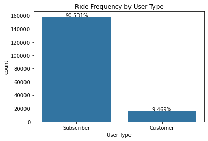

```python
ax = sb.countplot(data = GoBike, x = 'user_type',  color=sb.color_palette()[0], order=GoBike.user_type.value_counts().index)

total = len(GoBike)
for p in ax.patches:
    percentage = '{:.3f}%'.format(100 * p.get_height()/total)
    x = p.get_x() + p.get_width()/2
    y = p.get_height()+.05
    ax.annotate(percentage, (x, y),ha='center')
plt.xlabel('User Type')
plt.title('Ride Frequency by User Type');
```

## Distribution of Rides by Days

Most rides were taken on Thursdays and Tuesdays. Weekends have the lowest trip records.

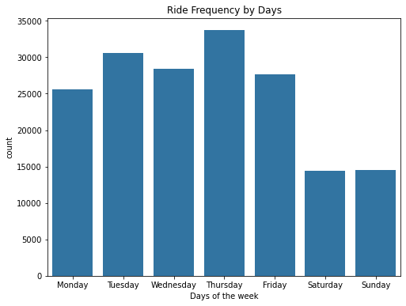

```python
plt.figure(figsize = (8,6))
sb.countplot(data = GoBike, x = 'start_day', color = sb.color_palette()[0])
plt.xlabel('Days of the week')
plt.title('Ride Frequency by Days');
```

## Distribution of Rides by Hours

The higher ride frequencies for morning (8th and 9th hours) and evening (17th and 18th hours) can be linked to rush hours where people leave for work and come back later in the evening.

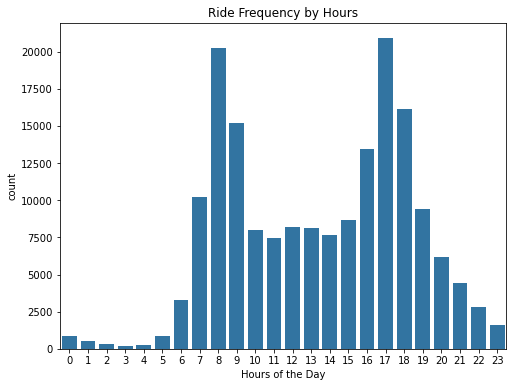

```python
plt.figure(figsize = (8,6))
sb.countplot(data = GoBike, x = 'start_hr', color = sb.color_palette()[0])
plt.xlabel('Hours of the Day')
plt.title('Ride Frequency by Hours');
```

## Trip Duration across Customer Types

Customer user type trips take a longer duration than subscriber user type

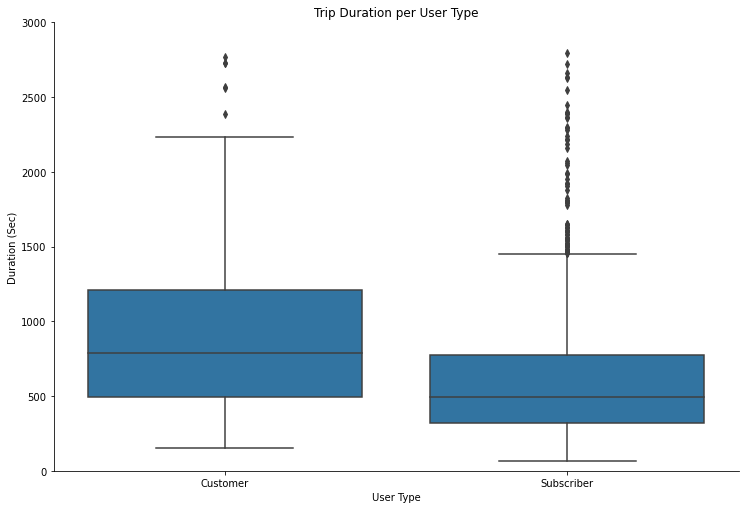

```python
samples = np.random.choice(GoBike.shape[0], 2000, replace = False)
diamonds_samp = GoBike.iloc[samples,:]

plt.figure(figsize = [6, 6])
def boxgrid(x, y, **kwargs):
    """ Quick hack for creating box plots with seaborn's PairGrid. """
    default_color = sb.color_palette()[0]
    sb.boxplot(x, y, color = default_color)

g = sb.PairGrid(data = diamonds_samp, y_vars = 'duration_sec', x_vars =  'user_type',
                size = 7, aspect = 1.5)
g.map(boxgrid)

plt.ylim([0,3000])
plt.xlabel('User Type')
plt.title('Trip Duration per User Type')
plt.ylabel('Duration (Sec)');
```